## # Week 5 Exercises

```r
#Read in data, explore, and make country col -> rownames
human <- read.csv("human_filtered.csv")
dim(human)
```

```
## [1] 155  10
```

```r
#There is an extra column for row number "X" so lets remove that
human$X <- NULL
str(human)
```

```
## 'data.frame':    155 obs. of  9 variables:
##  $ country           : chr  "Norway" "Australia" "Switzerland" "Denmark" ...
##  $ f_m_edu           : num  1.007 0.997 0.983 0.989 0.969 ...
##  $ f_m_labour        : num  0.891 0.819 0.825 0.884 0.829 ...
##  $ expected_edu      : num  17.5 20.2 15.8 18.7 17.9 16.5 18.6 16.5 15.9 19.2 ...
##  $ life_exp          : num  81.6 82.4 83 80.2 81.6 80.9 80.9 79.1 82 81.8 ...
##  $ gni               : int  64992 42261 56431 44025 45435 43919 39568 52947 42155 32689 ...
##  $ maternal_mortality: int  4 6 6 5 6 7 9 28 11 8 ...
##  $ adolesc_birth     : num  7.8 12.1 1.9 5.1 6.2 3.8 8.2 31 14.5 25.3 ...
##  $ repr_parl         : num  39.6 30.5 28.5 38 36.9 36.9 19.9 19.4 28.2 31.4 ...
```

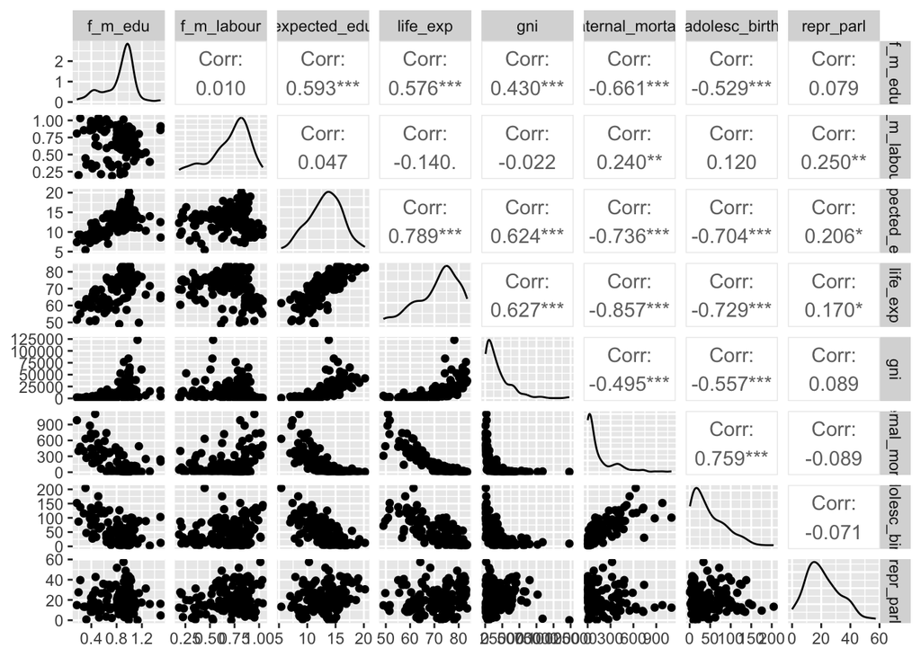

```r
rownames(human) <- human$country
human$country <- NULL

#Graphical overview
library(GGally)
ggpairs(human)
```

```r
summary(human)
```

```
##     f_m_edu         f_m_labour      expected_edu      life_exp
##  Min.   :0.1717   Min.   :0.1857   Min.   : 5.40   Min.   :49.00
##  1st Qu.:0.7264   1st Qu.:0.5984   1st Qu.:11.25   1st Qu.:66.30
##  Median :0.9375   Median :0.7535   Median :13.50   Median :74.20
##  Mean   :0.8529   Mean   :0.7074   Mean   :13.18   Mean   :71.65
##  3rd Qu.:0.9968   3rd Qu.:0.8535   3rd Qu.:15.20   3rd Qu.:77.25
##  Max.   :1.4967   Max.   :1.0380   Max.   :20.20   Max.   :83.50
##       gni         maternal_mortality adolesc_birth      repr_parl
##  Min.   :   581   Min.   :   1.0     Min.   :  0.60   Min.   : 0.00
##  1st Qu.:  4198   1st Qu.:  11.5     1st Qu.: 12.65   1st Qu.:12.40
##  Median : 12040   Median :  49.0     Median : 33.60   Median :19.30
##  Mean   : 17628   Mean   : 149.1     Mean   : 47.16   Mean   :20.91
##  3rd Qu.: 24512   3rd Qu.: 190.0     3rd Qu.: 71.95   3rd Qu.:27.95
##  Max.   :123124   Max.   :1100.0     Max.   :204.80   Max.   :57.50
```

Observing the results of ggpairs, we see that only expected years of education (expected_edu) is the only variable following a normal distribution, other variables seem to be skewed. Life expectancy and expected years of education are strongly correlated positively, other positively correlated pairs of variables are expected edu and gni, maternal mortality ratio and adolescent birth rate.

Next we perform a principal component analysis which is a form of dimensionality reduction and tells us how much of the variablity of the data is explained by some of the variables, or principal components and draw a biplot to visualize the results.

```r
# PCA and summary
pca_human <- prcomp(human)
s <- summary(pca_human)
pca_pr <- round(1*s$importance[2, ], digits = 5)
print(pca_pr)
```

```
##    PC1    PC2    PC3    PC4    PC5    PC6    PC7    PC8
## 0.9999 0.0001 0.0000 0.0000 0.0000 0.0000 0.0000 0.0000
```

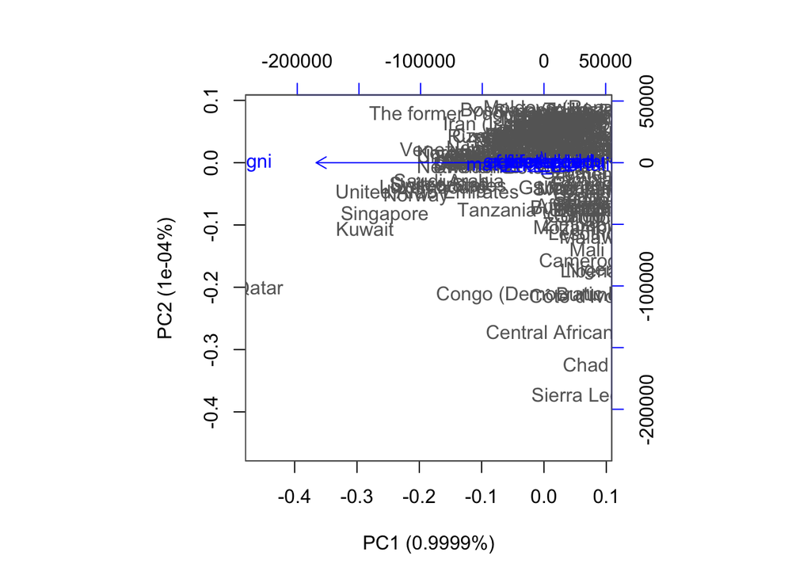

```r
pc_lab <- paste0(names(pca_pr), " (", pca_pr, "%)")

# Biplot
biplot(pca_human, cex = c(1, 1), col = c("grey40", "blue"), xlab = pc_lab[1], ylab = pc_lab[2])
```

The PCA with the raw data shows that one variable, gni, explains 99% of the variability in the data.

Next we standardize the data and repeat the analysis

```r
# Scale data
human_scaled <- scale(human)

# Repeat PCA with scaled data
pca_human_s <- prcomp(human_scaled)
s_scaled <- summary(pca_human_s)
pca_pr_scaled <- round(1*s_scaled$importance[2, ], digits = 5)
print(pca_pr_scaled)
```

```
##     PC1     PC2     PC3     PC4     PC5     PC6     PC7     PC8
## 0.53605 0.16237 0.09571 0.07583 0.05477 0.03595 0.02634 0.01298
```

[figure not shown]

```r
pc_lab_scaled <- paste0(names(pca_pr_scaled), " (", pca_pr, "%)")

# Biplot
fig.width=10
biplot(pca_human_s, cex = c(0.8, 1), col = c("grey40", "blue"), xlab = pc_lab_scaled[1], ylab = pc_lab_scaled[2])
```

With the scaled data, PC1 explains 53% of the variability and PC2 explains 16% of the variability. This differs from the results of raw data, where it seemed like PC1 explained all of the variability (99%). In the raw data, gni so gross national income explained all the variability. After standardization, female to male labour ratio and Percent Representation in Parliament explained variability on the y axis, and other variables explain the variance of x axis so PC1.

Now we continue with tea dataset from FactoMine package, we explore the data and then perform an MCA analysis

```r
#Load data, explore structure and dimensions
tea <- read.csv("https://raw.githubusercontent.com/KimmoVehkalahti/Helsinki-Open-Data-Science/master/datasets/tea.csv", stringsAsFactors = TRUE)
str(tea)
```

```
## 'data.frame':    300 obs. of  36 variables:
##  $ breakfast       : Factor w/ 2 levels "breakfast","Not.breakfast": 1 1 2 2 1 2 1 2 1 1 ...
##  $ tea.time        : Factor w/ 2 levels "Not.tea time",..: 1 1 2 1 1 1 2 2 2 1 ...
##  $ evening         : Factor w/ 2 levels "evening","Not.evening": 2 2 1 2 1 2 2 1 2 1 ...
##  $ lunch           : Factor w/ 2 levels "lunch","Not.lunch": 2 2 2 2 2 2 2 2 2 2 ...
##  $ dinner          : Factor w/ 2 levels "dinner","Not.dinner": 2 2 1 1 2 1 2 2 2 2 ...
##  $ always          : Factor w/ 2 levels "always","Not.always": 2 2 2 2 1 2 2 2 2 2 ...
##  $ home            : Factor w/ 2 levels "home","Not.home": 1 1 1 1 1 1 1 1 1 1 ...
##  $ work            : Factor w/ 2 levels "Not.work","work": 1 1 2 1 1 1 1 1 1 1 ...
##  $ tearoom         : Factor w/ 2 levels "Not.tearoom",..: 1 1 1 1 1 1 1 1 1 2 ...
##  $ friends         : Factor w/ 2 levels "friends","Not.friends": 2 2 1 2 2 2 1 2 2 2 ...
##  $ resto           : Factor w/ 2 levels "Not.resto","resto": 1 1 2 1 1 1 1 1 1 1 ...
##  $ pub             : Factor w/ 2 levels "Not.pub","pub": 1 1 1 1 1 1 1 1 1 1 ...
##  $ Tea             : Factor w/ 3 levels "black","Earl Grey",..: 1 1 2 2 2 2 2 1 2 1 ...
##  $ How             : Factor w/ 4 levels "alone","lemon",..: 1 3 1 1 1 1 1 3 3 1 ...
```

[output cut: 22 more lines]

```r
dim(tea)
```

```
## [1] 300  36
```

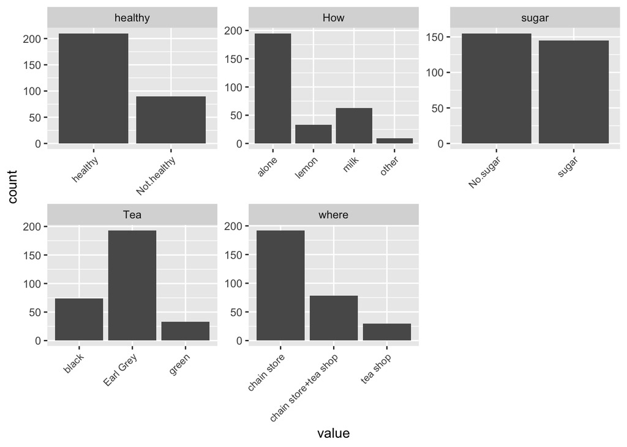

```r
#Visualize the data
library(ggplot2)
library(dplyr)
library(tidyr)
#select some columns to visualize because there are many hard to visualise and imo some useless columns
tea_cols <- dplyr::select(tea, Tea, How, sugar, where, healthy)
pivot_longer(tea_cols, cols = everything()) %>%
  ggplot(aes(value)) + geom_bar() + facet_wrap("name", scales = "free") + theme(axis.text.x = element_text(angle = 45, hjust = 1, size = 8))
```

Now we perform Multiple Correspondence Analysis (MCA) on the tea data.

```r
# MCA
library(FactoMineR)
library(factoextra)
```

```r
mca_tea <- MCA(tea_cols, graph = FALSE)
summary(mca_tea)
```

```
##
## Call:
## MCA(X = tea_cols, graph = FALSE)
##
##
## Eigenvalues
##                        Dim.1   Dim.2   Dim.3   Dim.4   Dim.5   Dim.6   Dim.7
## Variance               0.276   0.264   0.240   0.203   0.202   0.181   0.167
## % of var.             15.336  14.659  13.327  11.265  11.198  10.080   9.279
## Cumulative % of var.  15.336  29.995  43.322  54.587  65.785  75.865  85.144
##                        Dim.8   Dim.9
## Variance               0.144   0.124
## % of var.              7.980   6.876
## Cumulative % of var.  93.124 100.000
##
## Individuals (the 10 first)
##                Dim.1    ctr   cos2    Dim.2    ctr   cos2    Dim.3    ctr
## 1           |  0.126  0.019  0.014 | -0.175  0.039  0.027 | -0.296  0.122
## 2           |  0.622  0.467  0.221 | -0.280  0.099  0.045 | -0.461  0.295
## 3           | -0.064  0.005  0.007 | -0.286  0.104  0.136 | -0.261  0.095
## 4           | -0.411  0.204  0.267 |  0.105  0.014  0.017 | -0.205  0.058
## 5           | -0.417  0.210  0.177 | -0.168  0.036  0.029 | -0.361  0.181
## 6           | -0.064  0.005  0.007 | -0.286  0.104  0.136 | -0.261  0.095
## 7           | -0.064  0.005  0.007 | -0.286  0.104  0.136 | -0.261  0.095
## 8           |  0.622  0.467  0.221 | -0.280  0.099  0.045 | -0.461  0.295
## 9           |  0.150  0.027  0.011 |  0.536  0.362  0.137 | -0.195  0.053
## 10          |  0.889  0.955  0.507 | -0.150  0.028  0.014 | -0.078  0.008
##               cos2
## 1            0.078 |
## 2            0.121 |
## 3            0.113 |
## 4            0.067 |
## 5            0.132 |
## 6            0.113 |
## 7            0.113 |
## 8            0.121 |
## 9            0.018 |
## 10           0.004 |
##
## Categories (the 10 first)
```

[output cut: 15 more lines]

```
## alone       |  -0.162   1.414   0.048  -3.806 |
## lemon       |   1.931  34.198   0.461  11.739 |
## milk        |  -0.427   3.198   0.049  -3.810 |
## other       |  -0.589   0.868   0.011  -1.791 |
## No.sugar    |  -0.066   0.189   0.005  -1.183 |
## sugar       |   0.071   0.202   0.005   1.183 |
## chain store |  -0.432   9.939   0.331  -9.950 |
##
## Categorical variables (eta2)
##               Dim.1 Dim.2 Dim.3
## Tea         | 0.364 0.451 0.116 |
## How         | 0.405 0.290 0.476 |
## sugar       | 0.207 0.252 0.005 |
## where       | 0.224 0.306 0.590 |
## healthy     | 0.181 0.020 0.012 |
```

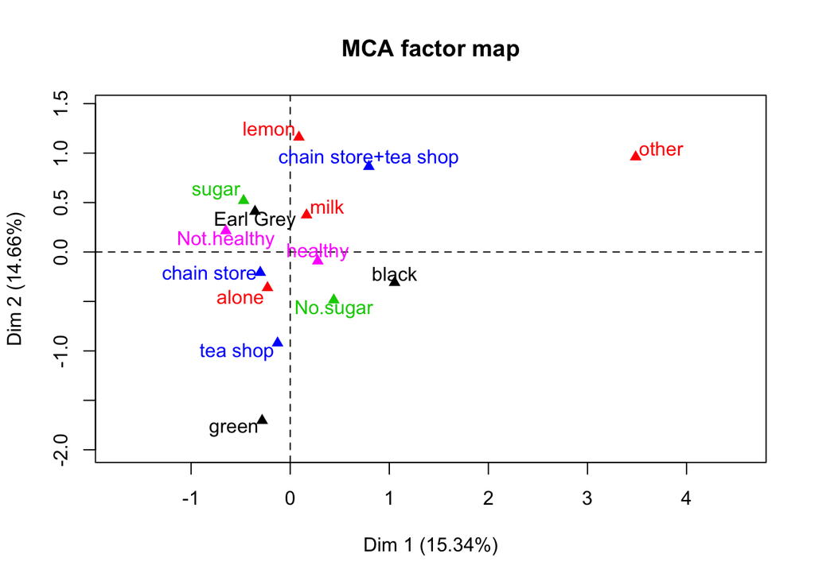

```r
# Visualize
plot(mca_tea, invisible=c("ind"), graph.type = "classic", habillage = "quali")
```

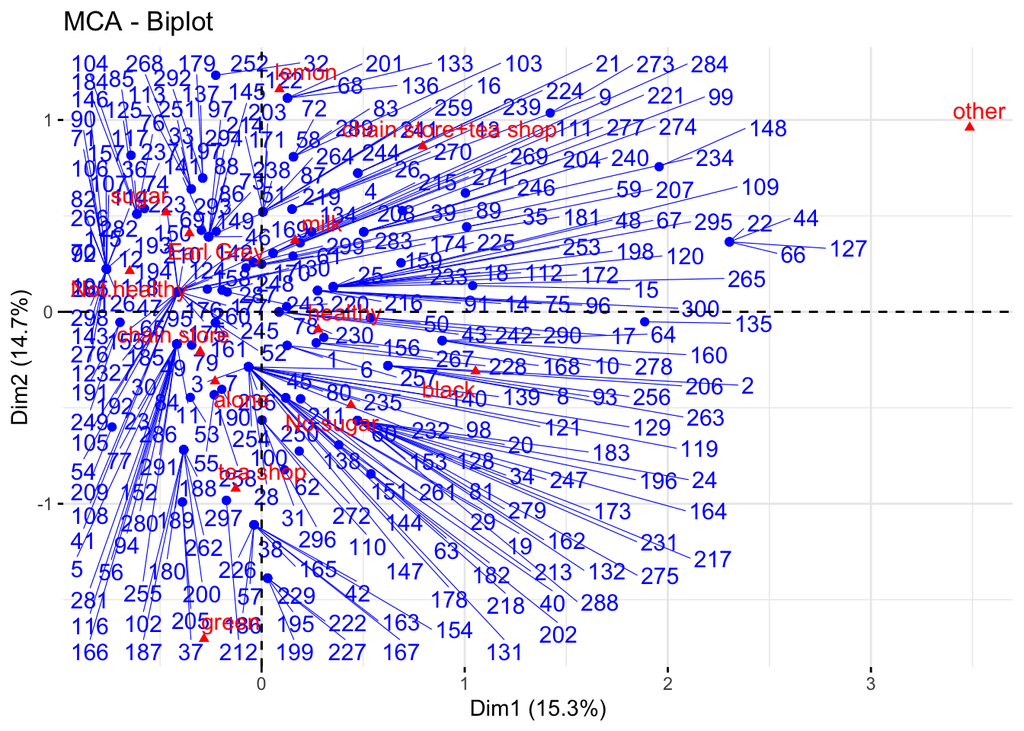

```r
fviz_mca_biplot(mca_tea,
               repel = TRUE, # Avoid text overlapping (slow if many point)
               ggtheme = theme_minimal())
```

From the results we look at the variables with positive dimensions such as black, no sugar, other, lemon, milk which are the most linked, and negative varibales are the least linked such as green, tea shop, chain store. Variance explained by dimension one and dimension two was 15.34% and 14.66%, respectively. No clear clusters appear on the factor map.